# Controlling - Forecasting Project

Load all libraries and data we need

```r
# Load all libraries
suppressWarnings(library(xts))
suppressWarnings(library(forecast))
suppressWarnings(library(ggplot2))
# Load the given data and preconstruct a basic timeseries out of the xts
candles.xts <- readRDS("DataCMI")
candles.xts$ABC <- NULL
candles.ts <- ts(candles.xts, frequency=5*52)
# max axis scaling for equal plots
scale.A <- c(1,130000)
scale.B <- c(1,150000)
scale.C <- c(1,25000)
scale.ABC <- c(1,scale.A[2]+scale.B[2]+scale.C[2])
```

Some basic helper functions that we’ll need along the way

```r
# Converts the mean + CI of a standard forecast object into a data.frame
forecast2dataframe <- function(fc, doCumsum=FALSE) {
   # upper/lower: col 2 is the 95% interval, col 1 is the 80%

  if (doCumsum) {
    df <- data.frame(cumsum(fc$mean), cumsum(fc$lower[,2]), cumsum(fc$upper[,2]))
  }
  else {
    df <- data.frame(fc$mean, fc$lower[,2], fc$upper[,2])
  }

  colnames(df) <- c("mean", "lower", "upper")
  df$time = rownames(df)

  return(df)
}
# Converts the mean + CI of a standard predict object into a data.frame
predict2dataframe <- function(predict, doCumsum=FALSE) {
  if (doCumsum) {
    df <- data.frame(cumsum(predict[,"fit"]), cumsum(predict[,"lwr"]), cumsum(predict[,"upr"]))
  }
  else {
    df <- data.frame(predict[,"fit"], predict[,"lwr"], predict[,"upr"])
  }

  colnames(df) <- c("mean", "lower", "upper")
  df$time = 1:nrow(df)

  return(df)
}
# Plots a given forecast data.frame
cumsumplot <- function(fc, title, ylimits, color="black", additivePlot=-1) {
  if (additivePlot == 1) {
    lines(x=fc$time,  y=fc$mean,  type="l", col=color)
  }
  else {
    plot(x=fc$time,  y=fc$mean,  type="l", col=color, ylim=ylimits, xlab="time", ylab="sales", main=title)

    if (additivePlot == -1) {
      lines(x=fc$time, y=fc$lower, col="red", lty="dotted")
      lines(x=fc$time, y=fc$upper, col="blue", lty="dotted")

      legend(x="topleft", legend=c("mean", "lower", "upper"), col=c("black", "red", "blue"), lty=c("solid", "dotted", "dotted"))
    }
  }
}
# Plots three forecast data.frames (as sum)
ccumsumplot <- function(fc1, fc2, fc3, title, ylimits, color="black", additivePlot=-1) {
  if (additivePlot == 1) {
    lines(x=fc1$time,  y=fc1$mean+fc2$mean+fc3$mean, type="l", col=color)
  }
  else {
    plot(x=fc1$time,  y=fc1$mean+fc2$mean+fc3$mean,    type="l", col=color, ylim=ylimits, xlab="time", ylab="sales", main=title)

    if (additivePlot == -1) {
      lines(x=fc1$time, y=fc1$lower+fc2$lower+fc3$lower, col="red", lty="dotted")
      lines(x=fc1$time, y=fc1$upper+fc2$upper+fc3$upper, col="blue", lty="dotted")

      legend(x="topleft", legend=c("mean", "lower", "upper"), col=c("black", "red", "blue"), lty=c("solid", "dotted", "dotted"))
    }
  }
}
```

Quick overview of the loaded data: A - “gegossene Kerzen” B - “gepresste Kerzen” C - “gezogene Kerzen”

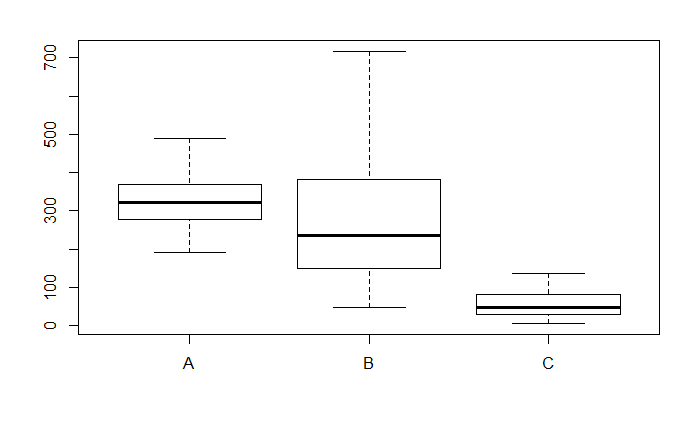

```r
boxplot(candles.ts)
```

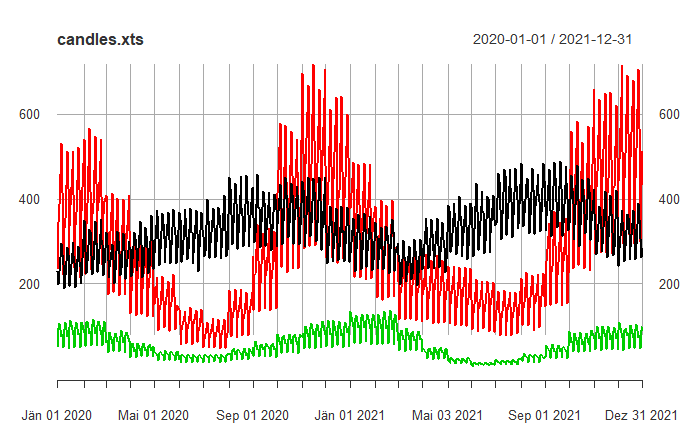

```r
plot(candles.xts)
```

### Part 1 - Daily - Timeseries forecasting

First, try an automated forecast using the “forecast” package (the most important part for this to work is setting the frequency of possible seasonality during creation of the timeseries!)

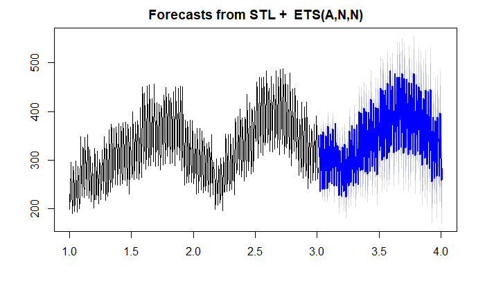

```r
# Specify one seasonality manually:
# 365.25 days per year on average (accounting for leap-years)
# 7 days a week normally
# 5 days a week in our dataset (since we skip weekends)
# Do an automated forecast (this uses STL - "Seasonal Decomposition Of Time Series" and ETS - "Exponential Smoothing State Space Model")
forecast.ts.auto <- forecast(candles.ts, 365.25/7*5)
# Plot the basic forecasts
plot(forecast.ts.auto$forecast$A)
```

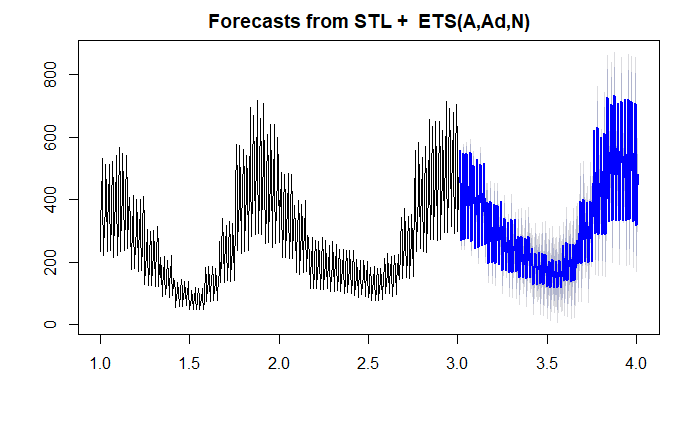

```r
plot(forecast.ts.auto$forecast$B)
```

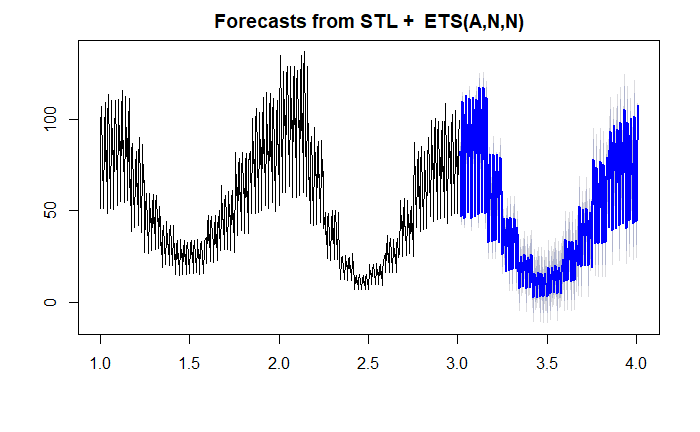

```r
plot(forecast.ts.auto$forecast$C)
```

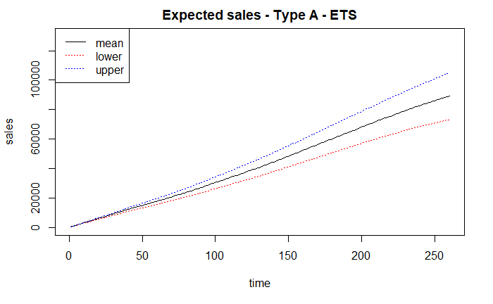

```r
# Convert them into dataframes for better plotting
forecast.ts.auto.agg.A <- forecast2dataframe(forecast.ts.auto$forecast$A, TRUE)
forecast.ts.auto.agg.B <- forecast2dataframe(forecast.ts.auto$forecast$B, TRUE)
forecast.ts.auto.agg.C <- forecast2dataframe(forecast.ts.auto$forecast$C, TRUE)
# Plot the trajectories through the predicted year
cumsumplot(forecast.ts.auto.agg.A, "Expected sales - Type A - ETS", scale.A)
```

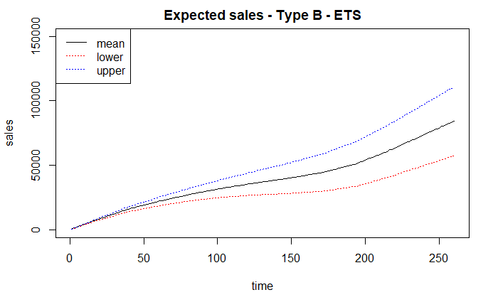

```r
cumsumplot(forecast.ts.auto.agg.B, "Expected sales - Type B - ETS", scale.B)
```

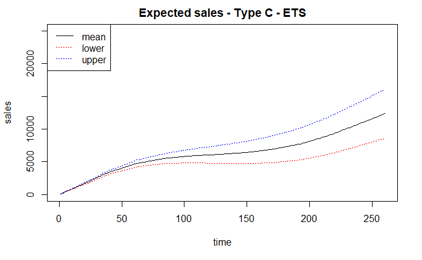

```r
cumsumplot(forecast.ts.auto.agg.C, "Expected sales - Type C - ETS", scale.C)
```

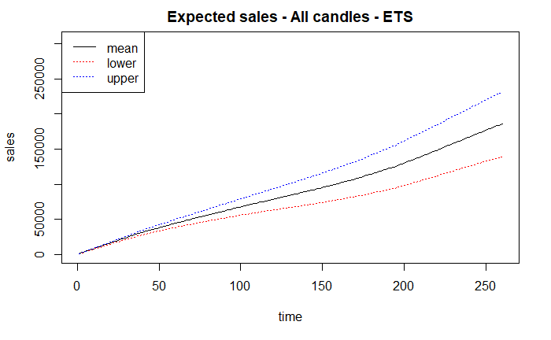

```r
# Plot the accumulated trajectory through the year (all candle sales)
ccumsumplot(forecast.ts.auto.agg.A, forecast.ts.auto.agg.B, forecast.ts.auto.agg.C, "Expected sales - All candles - ETS", scale.ABC)
```

The problem is though, that we can clearly see there are more seasonal components in the sales data (ETS can’t handle that). Another try with a more sophisticated timeseries forecasts (TBATS) (see https://robjhyndman.com/hyndsight/dailydata/, ?tbats, De Livera, Hyndman & Snyder (2011), …)

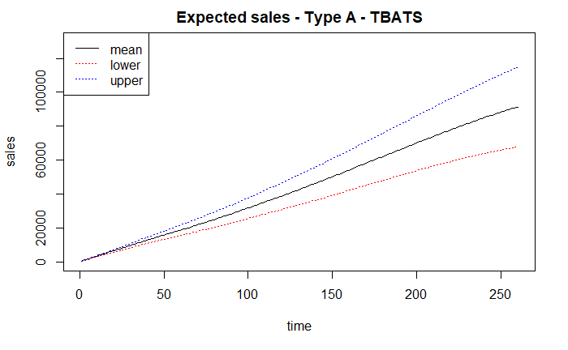

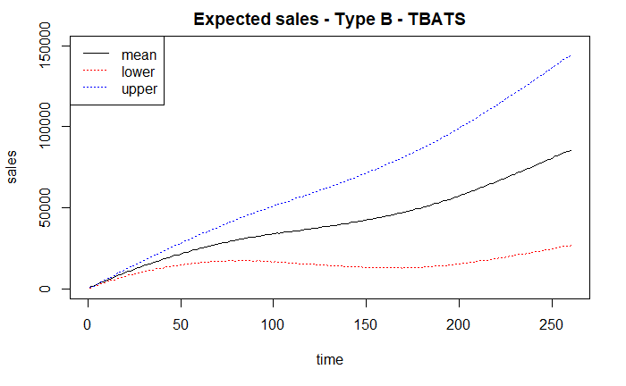

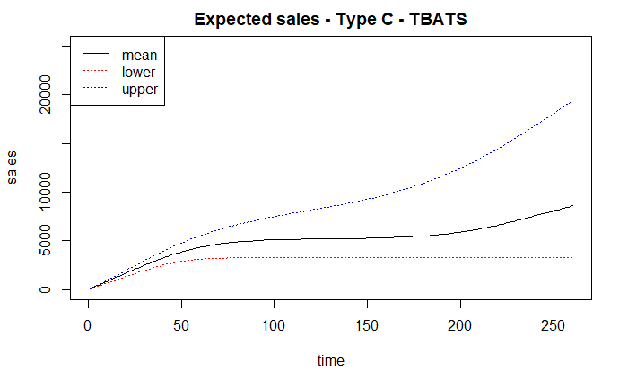

```r
# Convert them into dataframes for better plotting
forecast.ts.tbats.agg.A <- forecast2dataframe(forecast.ts.tbats.A, TRUE)
forecast.ts.tbats.agg.B <- forecast2dataframe(forecast.ts.tbats.B, TRUE)
forecast.ts.tbats.agg.C <- forecast2dataframe(forecast.ts.tbats.C, TRUE)
# Plot the trajectories through the predicted year
cumsumplot(forecast.ts.tbats.agg.A, "Expected sales - Type A - TBATS", scale.A)
cumsumplot(forecast.ts.tbats.agg.B, "Expected sales - Type B - TBATS", scale.B)

cumsumplot(forecast.ts.tbats.agg.C, "Expected sales - Type C - TBATS", scale.C)
```

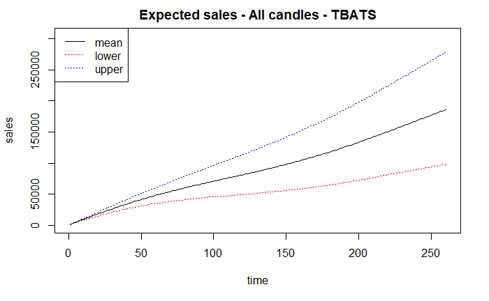

```r
# Plot the accumulated trajectory through the year (all candle sales)
ccumsumplot(forecast.ts.tbats.agg.A, forecast.ts.tbats.agg.B, forecast.ts.tbats.agg.C, "Expected sales - All candles - TBATS", scale.ABC)
```

### Part 2 - Daily - Regression based forecasting

First, add some additional data to the timeseries that we can regress on (year, month, day, …)

```r
# Extract some infos that are (atleast partially) statisically significant
candles.xts$year       <- as.factor(format(index(candles.xts),"%Y"))
candles.xts$quarter    <- as.factor(quarters(index(candles.xts)))
candles.xts$month      <- as.factor(format(index(candles.xts),"%m"))
candles.xts$dayOfWeek  <- as.factor(format(index(candles.xts),"%u"))
# candles.xts$dayOfMonth <- format(index(candles.xts),"%d")  # this doesn't seem to have any statistical significance - drop it
# candles.xts$week       <- format(index(candles.xts),"%V")  # this doesn't seem to have any statistical significance - drop it
```

Regress now: (be careful - if we use year only as a factor, we need to also create that while predicting. Since the model only “learns” about two factors - year 1 & 2 - we can only manually assume it’s going to be more like year 1 or 2. ) Therefore we don’t use it as a factor and can then capture a simple yearly trend

```r
# Build some basic linear regression models, give the summary and plot the residuals
model.reg.A <- lm(A ~ year + as.factor(quarter) + as.factor(month) + as.factor(dayOfWeek), data=candles.xts)
summary(model.reg.A)
```

```
Call:
lm(formula = A ~ year + as.factor(quarter) + as.factor(month) +
    as.factor(dayOfWeek), data = candles.xts)

Residuals:
    Min      1Q  Median      3Q     Max
-42.583 -11.729   0.389  11.829  55.528

Coefficients: (3 not defined because of singularities)
                      Estimate Std. Error t value Pr(>|t|)
(Intercept)            307.331      3.964  77.538  < 2e-16 ***
year                    19.226      1.591  12.085  < 2e-16 ***
as.factor(quarter)2     57.827      3.880  14.904  < 2e-16 ***
as.factor(quarter)3    107.298      3.879  27.661  < 2e-16 ***
as.factor(quarter)4     45.259      3.836  11.798  < 2e-16 ***
as.factor(month)2       14.325      3.974   3.605 0.000344 ***
as.factor(month)3      -16.831      3.859  -4.361 1.57e-05 ***
as.factor(month)4      -41.964      3.880 -10.816  < 2e-16 ***
as.factor(month)5       -9.488      3.925  -2.418 0.015977 *
as.factor(month)6           NA         NA      NA       NA
as.factor(month)7      -20.169      3.857  -5.229 2.50e-07 ***
as.factor(month)8        3.399      3.902   0.871 0.384129
as.factor(month)9           NA         NA      NA       NA
as.factor(month)10      58.843      3.859  15.248  < 2e-16 ***
as.factor(month)11      34.656      3.860   8.977  < 2e-16 ***
as.factor(month)12          NA         NA      NA       NA
as.factor(dayOfWeek)2  -33.141      2.523 -13.136  < 2e-16 ***
as.factor(dayOfWeek)3  -65.810      2.519 -26.125  < 2e-16 ***
as.factor(dayOfWeek)4 -129.798      2.520 -51.505  < 2e-16 ***
as.factor(dayOfWeek)5  -96.546      2.520 -38.314  < 2e-16 ***
---
Signif. codes:  0 *** 0.001 ** 0.01 * 0.05 . 0.1   1

Residual standard error: 18.19 on 506 degrees of freedom
Multiple R-squared:  0.9254,    Adjusted R-squared:  0.923
F-statistic: 392.1 on 16 and 506 DF,  p-value: < 2.2e-16
```

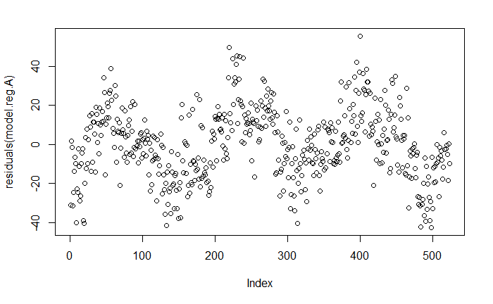

```r
plot(residuals(model.reg.A))
```

```r
model.reg.B <- lm(B ~ year + as.factor(quarter) + as.factor(month) + as.factor(dayOfWeek), data=candles.xts)
summary(model.reg.B)
```

```
Call:
lm(formula = B ~ year + as.factor(quarter) + as.factor(month) +
    as.factor(dayOfWeek), data = candles.xts)

Residuals:
     Min       1Q   Median       3Q      Max
-109.339  -27.957    0.389   30.178  143.964

Coefficients: (3 not defined because of singularities)
                      Estimate Std. Error t value Pr(>|t|)
(Intercept)            480.377      9.687  49.587  < 2e-16 ***
year                    -4.933      3.888  -1.269 0.205130
as.factor(quarter)2   -239.799      9.483 -25.288  < 2e-16 ***
as.factor(quarter)3   -120.700      9.481 -12.731  < 2e-16 ***
as.factor(quarter)4    100.953      9.376  10.768  < 2e-16 ***
as.factor(month)2      -28.091      9.713  -2.892 0.003991 **
as.factor(month)3     -122.315      9.432 -12.968  < 2e-16 ***
as.factor(month)4       76.658      9.482   8.084 4.64e-15 ***
as.factor(month)5       35.962      9.592   3.749 0.000198 ***
as.factor(month)6           NA         NA      NA       NA
as.factor(month)7     -135.050      9.428 -14.324  < 2e-16 ***
as.factor(month)8     -100.787      9.537 -10.568  < 2e-16 ***
as.factor(month)9           NA         NA      NA       NA
as.factor(month)10     -67.632      9.432  -7.171 2.67e-12 ***
as.factor(month)11       8.839      9.435   0.937 0.349322
as.factor(month)12          NA         NA      NA       NA
as.factor(dayOfWeek)2  -83.658      6.166 -13.567  < 2e-16 ***
as.factor(dayOfWeek)3 -218.134      6.157 -35.430  < 2e-16 ***
as.factor(dayOfWeek)4 -135.806      6.159 -22.049  < 2e-16 ***
as.factor(dayOfWeek)5 -108.345      6.159 -17.592  < 2e-16 ***
---
Signif. codes:  0 *** 0.001 ** 0.01 * 0.05 . 0.1   1

Residual standard error: 44.45 on 506 degrees of freedom
Multiple R-squared:  0.9165,    Adjusted R-squared:  0.9138
F-statistic: 346.9 on 16 and 506 DF,  p-value: < 2.2e-16
```

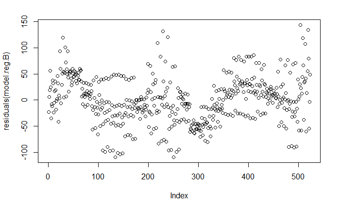

```r
plot(residuals(model.reg.B))
```

```r
model.reg.C <- lm(C ~ year + as.factor(quarter) + as.factor(month) + as.factor(dayOfWeek), data=candles.xts)
summary(model.reg.C)
```

```
Call:
lm(formula = C ~ year + as.factor(quarter) + as.factor(month) +
    as.factor(dayOfWeek), data = candles.xts)

Residuals:
     Min       1Q   Median       3Q      Max
-23.1253  -4.5344  -0.3595   4.7874  27.5802

Coefficients: (3 not defined because of singularities)
                      Estimate Std. Error t value Pr(>|t|)
(Intercept)            93.5979     1.8292  51.168  < 2e-16 ***
year                   -2.9769     0.7342  -4.054 5.82e-05 ***
as.factor(quarter)2   -73.0239     1.7906 -40.782  < 2e-16 ***
as.factor(quarter)3   -46.9761     1.7902 -26.241  < 2e-16 ***
as.factor(quarter)4    -9.4298     1.7703  -5.327 1.51e-07 ***
as.factor(month)2       2.8057     1.8341   1.530 0.126701
as.factor(month)3     -23.4821     1.7810 -13.185  < 2e-16 ***
as.factor(month)4      22.9188     1.7905  12.800  < 2e-16 ***
as.factor(month)5       7.0675     1.8112   3.902 0.000108 ***
as.factor(month)6           NA         NA      NA       NA
as.factor(month)7     -24.3094     1.7802 -13.655  < 2e-16 ***
as.factor(month)8     -13.6697     1.8008  -7.591 1.54e-13 ***
as.factor(month)9           NA         NA      NA       NA
as.factor(month)10    -19.0174     1.7810 -10.678  < 2e-16 ***
as.factor(month)11     -3.5531     1.7816  -1.994 0.046644 *
as.factor(month)12          NA         NA      NA       NA
as.factor(dayOfWeek)2   2.7927     1.1644   2.398 0.016825 *
as.factor(dayOfWeek)3 -19.2704     1.1625 -16.576  < 2e-16 ***
as.factor(dayOfWeek)4  11.7315     1.1630  10.087  < 2e-16 ***
as.factor(dayOfWeek)5  19.4235     1.1629  16.702  < 2e-16 ***
---
Signif. codes:  0 *** 0.001 ** 0.01 * 0.05 . 0.1   1

Residual standard error: 8.394 on 506 degrees of freedom
Multiple R-squared:  0.929, Adjusted R-squared:  0.9268
F-statistic: 414.1 on 16 and 506 DF,  p-value: < 2.2e-16
```

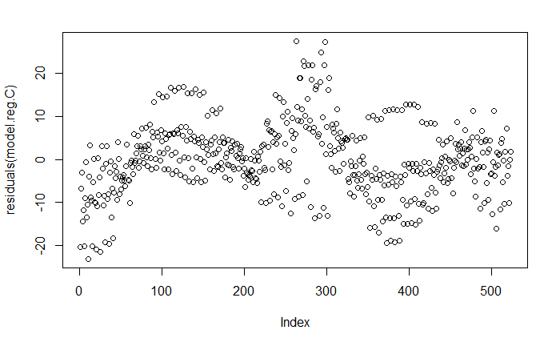

```r
plot(residuals(model.reg.C))
```

After regressing, build a forecast similar to the timeseries one before

```r
# Build a planning period (= input data) to forecast on
forecast.reg.xts            <- as.xts(seq(as.Date("2022-01-01"), as.Date("2022-12-31"),by='day'))
forecast.reg.xts$year       <- 3  # we "trust" the simple, linear trend
forecast.reg.xts$quarter    <- as.factor(quarters(index(forecast.reg.xts)))
forecast.reg.xts$month      <- as.factor(format(index(forecast.reg.xts), "%m"))
forecast.reg.xts$dayOfWeek  <- as.factor(format(index(forecast.reg.xts), "%u"))
# Exlude saturdays and sundays (since we got no sales there)
forecast.reg.xts            <- subset(forecast.reg.xts, !(forecast.reg.xts$dayOfWeek %in% c(6,7)))
# Predict the upcoming year, including a 95% CI
forecast.reg.A <- predict(model.reg.A, forecast.reg.xts, interval = "confidence", level=0.95)
```

[output not shown]

```r
forecast.reg.B <- predict(model.reg.B, forecast.reg.xts, interval = "confidence", level=0.95)
```

[output not shown]

```r
forecast.reg.C <- predict(model.reg.C, forecast.reg.xts, interval = "confidence", level=0.95)
```

[output not shown]

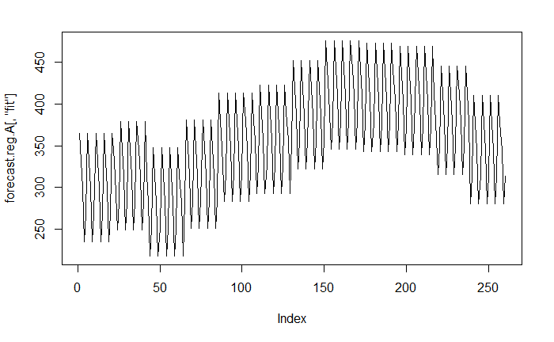

```r
# Plot the basic forecasts
plot(forecast.reg.A[,"fit"], type='l')
```

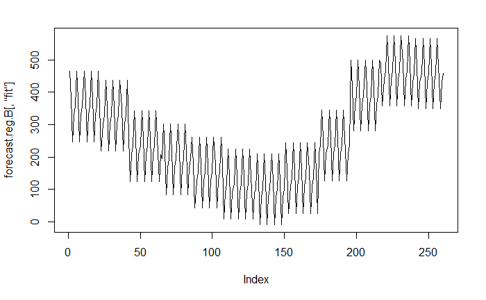

```r
plot(forecast.reg.B[,"fit"], type='l')
```

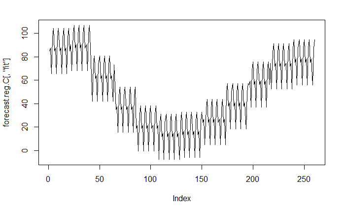

```r
plot(forecast.reg.C[,"fit"], type='l')
```

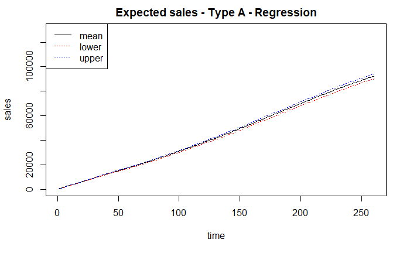

```r
# Convert them into dataframes for better plotting
forecast.reg.agg.A <- predict2dataframe(forecast.reg.A, TRUE)
forecast.reg.agg.B <- predict2dataframe(forecast.reg.B, TRUE)
forecast.reg.agg.C <- predict2dataframe(forecast.reg.C, TRUE)
# Plot the trajectories through the predicted year
cumsumplot(forecast.reg.agg.A, "Expected sales - Type A - Regression", scale.A)
```

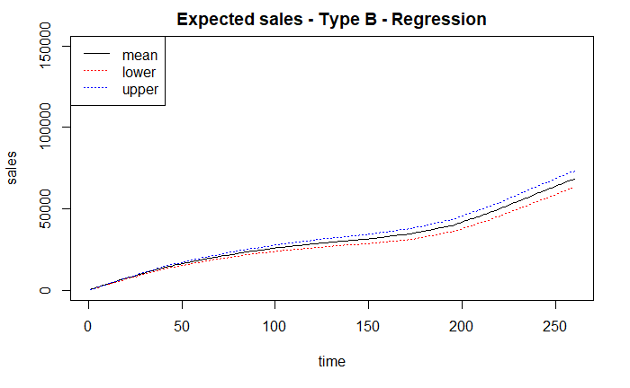

```r
cumsumplot(forecast.reg.agg.B, "Expected sales - Type B - Regression", scale.B)
```

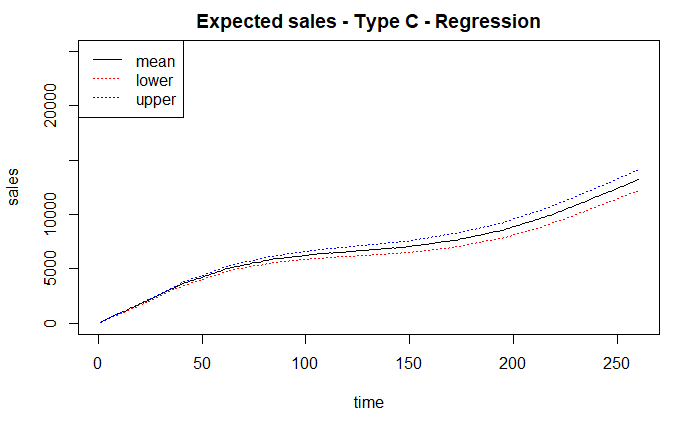

```r
cumsumplot(forecast.reg.agg.C, "Expected sales - Type C - Regression", scale.C)
```

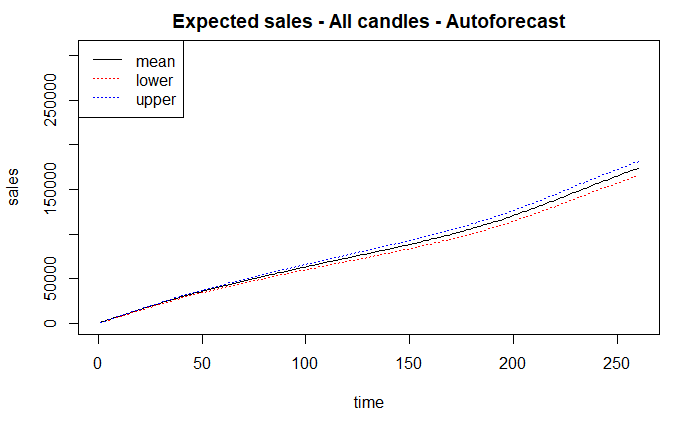

```r
# Plot the accumulated trajectory through the year (all candle sales)
ccumsumplot(forecast.reg.agg.A, forecast.reg.agg.B, forecast.reg.agg.C, "Expected sales - All candles - Autoforecast", scale.ABC)
```

### Part 3 - Quarterly - Stochastic process

First we “scale down” our data by reducing the frequency from daily to a quarterly measure.

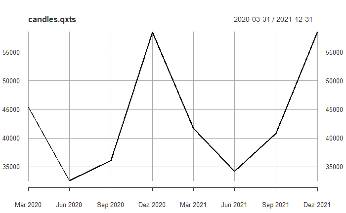

```r
# Extract the quarterly data and plot the trajectory through the given two years
candles.qxts <- apply.quarterly(candles.xts, sum)
colnames(candles.qxts) <- c("ABC")
plot(candles.qxts)
```

We now extract mean and variance of every quarter

```r
# Set up the used matrices
model.stoch.E  <- matrix(0, 1, 4)   # expected value
model.stoch.SD <- matrix(0, 1, 4)   # standard deviation
model.stoch.CV <- matrix(0, 1, 4)   # coefficient of variation
# Apply a min coefficient of variation. Why?
# We expect sales to vary by atleast X%. Sales staying the exact same over the course of several years can happen, but is extremely unlikely to happen again
minCV <- 0.05
# Set up the used matrices
model.stoch.SD.corr <- matrix(0, 1, 4)
model.stoch.CV.corr <- matrix(0, 1, 4)
# Apply readable column names
dimnames(model.stoch.E) <- list("ABC", c("Q1","Q2","Q3","Q4"))
dimnames(model.stoch.SD) <- list("ABC", c("Q1","Q2","Q3","Q4"))
dimnames(model.stoch.CV) <- list("ABC", c("Q1","Q2","Q3","Q4"))
dimnames(model.stoch.SD.corr) <- list("ABC", c("Q1","Q2","Q3","Q4"))
dimnames(model.stoch.CV.corr) <- list("ABC", c("Q1","Q2","Q3","Q4"))
# Calculate expected value, standard deviation and coefficient of variation for every quarter
for (q in 1:4) {
  model.stoch.E[1,q]  <- mean(candles.qxts[c(q,q+4),])
  model.stoch.SD[1,q] <- sd(candles.qxts[c(q,q+4),])
  model.stoch.CV[1,q] <- model.stoch.SD[1,q] / model.stoch.E[1,q]
}
# Correct the CV and SD by using the given min CV
model.stoch.CV.corr <- model.stoch.CV
model.stoch.CV.corr[model.stoch.CV.corr < minCV] <- minCV
model.stoch.SD.corr <- model.stoch.CV.corr * model.stoch.E
```

Plot some results

```r
# Density plots of every quarter
sales <- 25000:70000
plot(sales,  dnorm(sales, model.stoch.E[1], model.stoch.SD.corr[1]), col=1, type="l", ylim=c(0,0.0003), ylab="", main="Density - Quarterly")
lines(sales, dnorm(sales, model.stoch.E[2], model.stoch.SD.corr[2]), col=2)
```

```r
lines(sales, dnorm(sales, model.stoch.E[3], model.stoch.SD.corr[3]), col=3)
lines(sales, dnorm(sales, model.stoch.E[4], model.stoch.SD.corr[4]), col=4)
```

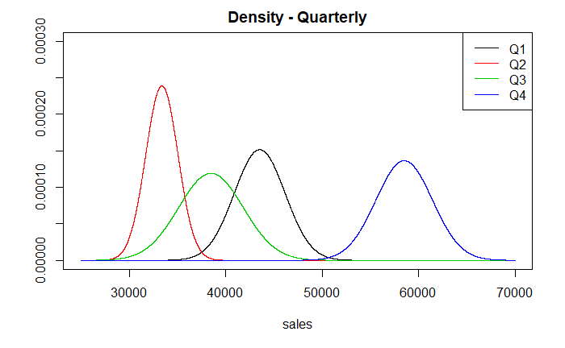

```r
legend("topright", legend=c("Q1","Q2","Q3","Q4"), col=1:4, lty=1)
```

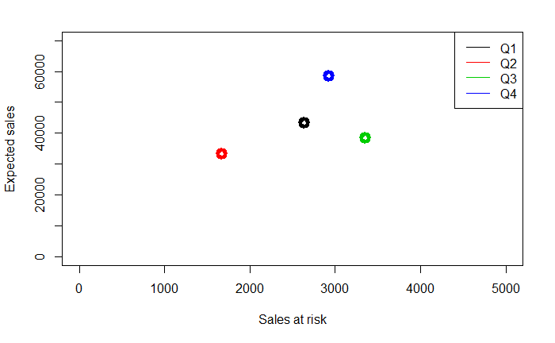

```r
# Sales at risk (expected sales over volatility) of every quarter
plot(x=model.stoch.SD.corr, y=model.stoch.E, col=1:4, xlab="Sales at risk", ylab="Expected sales", xlim=c(0,5000), ylim=c(0,70000), cex=1.5, lwd=5)
legend("topright", legend=c("Q1","Q2","Q3","Q4"), col=1:4, lty=1)
```

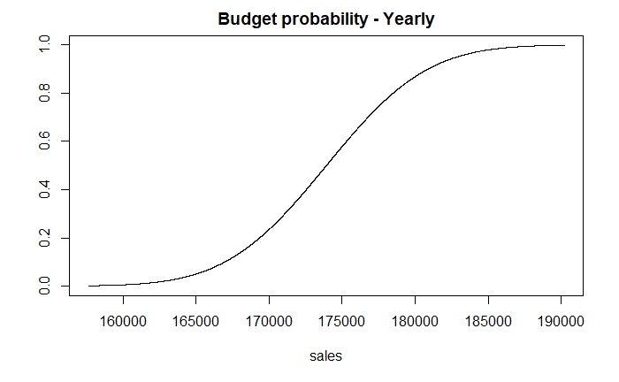

```r
# Plot the "stochastic" budget
yearE   <- cumsum(model.stoch.E)[4]
yearVol <- sqrt(cumsum((model.stoch.SD.corr)^2))[4]
plot(x=seq(yearE-3*yearVol,yearE+3*yearVol), y=pnorm(q=seq(yearE-3*yearVol,yearE+3*yearVol), mean=yearE, sd=yearVol), type="l", ylab="", xlab="sales", main="Budget probability - Yearly")
```

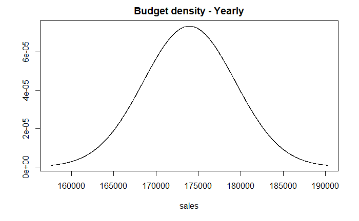

```r
plot(x=seq(yearE-3*yearVol,yearE+3*yearVol), y=dnorm(x=seq(yearE-3*yearVol,yearE+3*yearVol), mean=yearE, sd=yearVol), type="l", ylab="", xlab="sales", main="Budget density - Yearly")
```

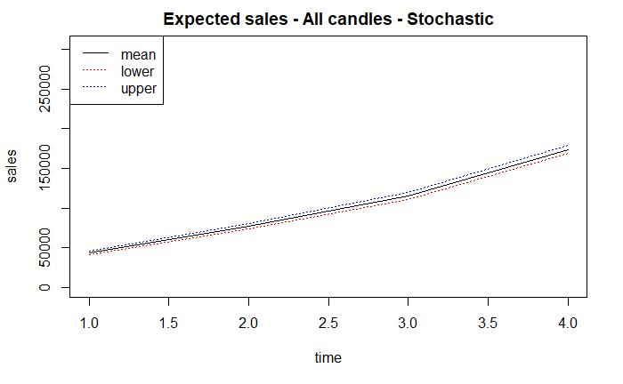

```r
# Prepare a data.frame for trajectory plotting
forecast.stoch <- data.frame(
  cumsum(model.stoch.E),
  cumsum(model.stoch.E) - sqrt(cumsum((model.stoch.SD.corr)^2)),
  cumsum(model.stoch.E) + sqrt(cumsum((model.stoch.SD.corr)^2))
)
colnames(forecast.stoch) <- c("mean", "lower", "upper")
forecast.stoch$time <- 1:4
# Plot the accumulated trajectory through the year (all candle sales)
cumsumplot(forecast.stoch, "Expected sales - All candles - Stochastic", scale.ABC)
```

Numeric results and combined plots of yearly trajectories

```r
n <- length(forecast.ts.auto.agg.A$mean)
interp <- approx(x=c(1,n/4,n/2,n*3/4,n), y=c(0,forecast.stoch$mean), xout=1:n)
forecast.stoch.interp <- data.frame(interp$x, interp$y)
colnames(forecast.stoch.interp) <- c("time", "mean")
ccumsumplot(forecast.ts.auto.agg.A, forecast.ts.auto.agg.B, forecast.ts.auto.agg.C, "Expected sales - All candles - Yearly trajectory", c(1,175000), color=1, 0)
ccumsumplot(forecast.ts.tbats.agg.A, forecast.ts.tbats.agg.B, forecast.ts.tbats.agg.C, "", scale.ABC, color=2, 1)
```

```r
ccumsumplot(forecast.reg.agg.A, forecast.reg.agg.B, forecast.reg.agg.C, "", scale.ABC, color=3, 1)
cumsumplot(forecast.stoch.interp, "", scale.ABC, color=4, 1)
```

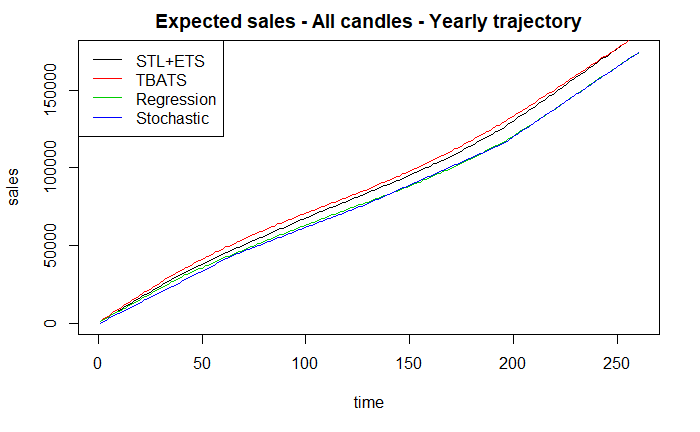

```r
legend(x="topleft", legend=c("STL+ETS", "TBATS", "Regression", "Stochastic"), col=1:4, lty=1)
```

```r
# STL + ETS
paste("------- STL + ETS -------")
```

```
[1] "------- STL + ETS -------"
```

```r
paste("Mean:  ", round(forecast.ts.auto.agg.A$mean + forecast.ts.auto.agg.B$mean + forecast.ts.auto.agg.C$mean)[length(forecast.ts.auto.agg.A$mean)])
```

```
[1] "Mean:   185613"
```

```r
paste("Lower: ", round(forecast.ts.auto.agg.A$lower + forecast.ts.auto.agg.B$lower + forecast.ts.auto.agg.C$lower)[length(forecast.ts.auto.agg.A$lower)])
```

```
[1] "Lower:  139253"
```

```r
paste("Upper: ", round(forecast.ts.auto.agg.A$upper + forecast.ts.auto.agg.B$upper + forecast.ts.auto.agg.C$upper)[length(forecast.ts.auto.agg.A$upper)])
```

```
[1] "Upper:  231974"
```

```r
# TBATS
paste("")
```

```
[1] ""
```

```r
paste("------- TBATS -------")
```

```
[1] "------- TBATS -------"
```

```r
paste("Mean:  ", round(forecast.ts.tbats.agg.A$mean + forecast.ts.tbats.agg.B$mean + forecast.ts.tbats.agg.C$mean)[length(forecast.ts.tbats.agg.A$mean)])
```

```
[1] "Mean:   185472"
```

```r
paste("Lower: ", round(forecast.ts.tbats.agg.A$lower + forecast.ts.tbats.agg.B$lower + forecast.ts.tbats.agg.C$lower)[length(forecast.ts.tbats.agg.A$lower)])
```

```
[1] "Lower:  97754"
```

```r
paste("Upper: ", round(forecast.ts.tbats.agg.A$upper + forecast.ts.tbats.agg.B$upper + forecast.ts.tbats.agg.C$upper)[length(forecast.ts.tbats.agg.A$upper)])
```

```
[1] "Upper:  278643"
```

```r
# Regression
paste("")
```

```
[1] ""
```

```r
paste("------- Regression -------")
```

```
[1] "------- Regression -------"
```

```r
paste("Mean:  ", round(forecast.reg.agg.A$mean + forecast.reg.agg.B$mean + forecast.reg.agg.C$mean)[length(forecast.reg.agg.A$mean)])
```

```
[1] "Mean:   173714"
```

```r
paste("Lower: ", round(forecast.reg.agg.A$lower + forecast.reg.agg.B$lower + forecast.reg.agg.C$lower)[length(forecast.reg.agg.A$lower)])
```

```
[1] "Lower:  165776"
```

```r
paste("Upper: ", round(forecast.reg.agg.A$upper + forecast.reg.agg.B$upper + forecast.reg.agg.C$upper)[length(forecast.reg.agg.A$upper)])
```

```
[1] "Upper:  181652"
```

```r
# Stochastic
paste("")
```

```
[1] ""
```

```r
paste("------- Stochastic -------")
```

```
[1] "------- Stochastic -------"
```

```r
paste("Mean:  ", round(forecast.stoch$mean)[length(forecast.stoch$mean)])
```

```
[1] "Mean:   173924"
```

```r
paste("Lower: ", round(forecast.stoch$lower)[length(forecast.stoch$lower)])
```

```
[1] "Lower:  168493"
```

```r
paste("Upper: ", round(forecast.stoch$upper)[length(forecast.stoch$upper)])
```

```
[1] "Upper:  179355"
```